# index (1)

Objetivo: reemplazar el bot simulado por el LLM local. Primero respuesta completa, luego en tiempo real.

Preparación

- Instala requests: pip install requests
- Instala Ollama y verifica que corre: curl http://localhost:11434
- Descarga modelo: ollama pull qwen2.5:3b

🧰 1. Verifica que Ollama esté instalado

Primero asegúrate de que Ollama está correctamente instalado y corriendo:

```python
ollama serve
```

O bien, abre otra ventana y prueba:

```python
curl http://localhost:11434
```

👉 Si responde con algo como {"models":[]} o un mensaje JSON, significa que Ollama está activo.

💾 2. Descargar el modelo Qwen2.5:3B

El comando en Windows es exactamente el mismo que en macOS o Linux, solo se ejecuta en PowerShell o CMD:

```python
ollama pull qwen2.5:3b
```

Este comando descargará el modelo desde los servidores de Ollama a tu máquina local. Dependiendo de tu conexión, puede tardar unos minutos (pesa varios GB).

✅ 3. Verifica que el modelo esté disponible

Una vez descargado, puedes confirmar que ya está instalado con:

```python
ollama list
```

Verás algo como:

```python
NAME             ID              SIZE      MODIFIED
qwen2.5:3b       123abc456def    4.2GB     2m ago
```

🚀 4. Probar el modelo localmente

Puedes probar que responde escribiendo:

```python
ollama run qwen2.5:3b
```

Te abrirá un entorno tipo chat directamente en la terminal. Para salir, escribe exit o presiona Ctrl + C.

Ahora continuemos con la construcción del chatbot.

Paso 1 — Imports y config Arriba de todo, agrega:

```python
import requests
import json

OLLAMA_URL = "http://localhost:11434/api/generate"
MODEL = "qwen2.5:3b"
```

Paso 2 — Llamada SIN streaming En enviar_click, sustituye la respuesta simulada por:

```python
try:
            r = requests.post(
                OLLAMA_URL,
                json={"model": MODEL, "prompt": texto, "stream": False},
                timeout=120,
            )
            r.raise_for_status()
            data = r.json()
            respuesta = data.get("response", "No hubo respuesta del modelo.")
            mensajes.controls.append(burbuja(respuesta, es_usuario=False))
            page.update()
        except Exception as ex:
            mensajes.controls.append(burbuja(f"Error: {ex}", es_usuario=False))
            page.update()
```

Prueba. Respuesta llega completa.

Paso 3 — Llamada CON streaming Crea una nueva función (déjala además de enviar_click):

```python
def enviar_click_streaming(e):
        texto = prompt.value.strip()
        if not texto:
            return
        mensajes.controls.append(burbuja(texto, es_usuario=True))
        page.update()
        prompt.value = ""
        page.update()

        live_text = ft.Text("", color=ft.Colors.BLACK, size=15, selectable=True)
        cont = ft.Row([
            ft.Container(content=live_text, bgcolor=ft.Colors.GREY_300, padding=12, border_radius=30, width=350),
        ], alignment=ft.MainAxisAlignment.START)
        mensajes.controls.append(cont)
        page.update()

        try:
            r = requests.post(
                OLLAMA_URL,
                json={"model": MODEL, "prompt": texto, "stream": True},
                stream=True,
                timeout=300,
            )
            r.raise_for_status()
            completo = ""
            for line in r.iter_lines():
                if not line:
                    continue
                data = json.loads(line)
                if "response" in data:
                    completo += data["response"]
                    live_text.value = completo
                    page.update()
        except Exception as ex:
            live_text.value = f"Error: {ex}"
            page.update()
```

Conecta el botón y on_submit a enviar_click_streaming:

```python
boton_enviar = ft.ElevatedButton("Enviar", on_click=enviar_click_streaming, bgcolor=ft.Colors.BLUE_400, color=ft.Colors.WHITE)
    prompt.on_submit = enviar_click_streaming
```

Prueba. Debe verse aparecer la respuesta en tiempo real.

Código final parte 2

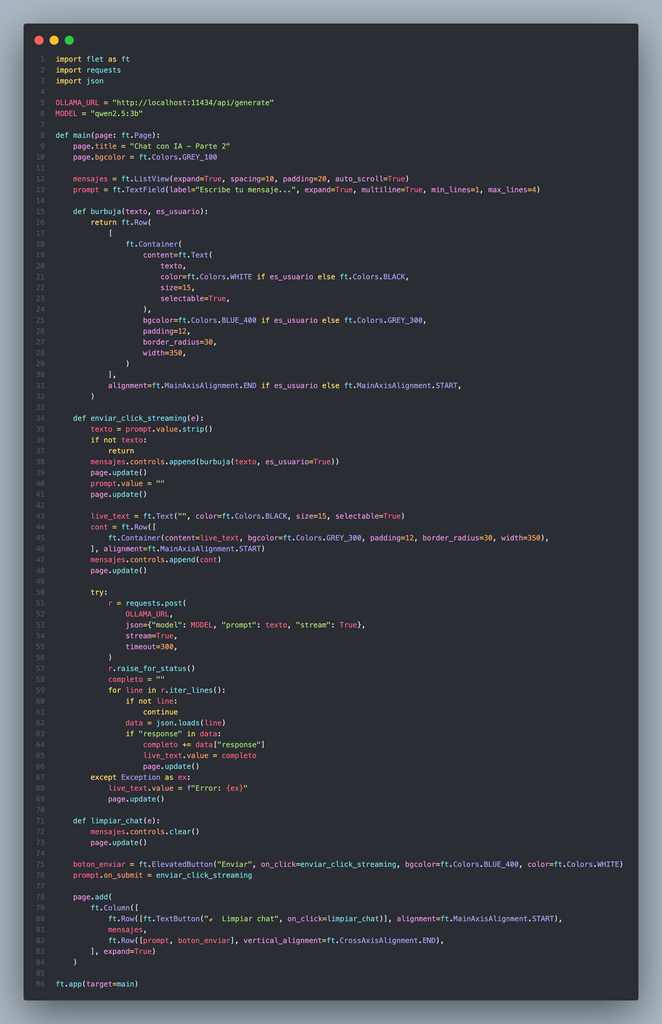